# Análisis Integral: PCA + Enriquecimiento Funcional

Estudio de Expresión Génica en Obesidad: Familia Simpson

Actividad 2 - RNA-Seq

2025-12-15

# 1 1. Introducción

Este análisis integra: - **PCA:** Validación de calidad y patrones globales - **Enriquecimiento GO:** Procesos biológicos alterados - **KEGG Pathways:** Rutas metabólicas implicadas

Datos: Family Simpson - Normopeso vs Obeso2 (37 genes candidatos de obesidad)

# 2 2. Preparación de Datos

## 2.1 2.1 Librerías principales

```r
if (!require("BiocManager", quietly = TRUE))
    install.packages("BiocManager")

library(DESeq2)
library(tximport)
library(ggplot2)
library(ggrepel)
library(dplyr)
library(tidyr)
library(gridExtra)
library(pheatmap)
library(vegan)

cat("✓ Librerías cargadas\n")
```

```
## ✓ Librerías cargadas
```

## 2.2 2.2 Cargar datos Simpson desde Resultados

```r
# Definir muestras
muestras <- c("BartSimpson", "LisaSimpson", "MaggieSimpson",
              "MargeSimpson", "PattyBouvier", "SelmaBouvier")

# RUTAS RELATIVAS: desde Codigo/ apuntamos a ../
resultados_path <- "../Resultados"
datos_path <- "../Datos"

# Rutas a los archivos quant.sf
paths <- file.path(resultados_path, paste0(muestras, "quant.sf"))
names(paths) <- muestras

cat("Buscando archivos Salmon quant.sf...\n")
```

```
## Buscando archivos Salmon quant.sf...
```

```r
archivos_encontrados <- file.exists(paths)
for (i in seq_along(paths)) {
  status <- ifelse(archivos_encontrados[i], "✓", "✗")
  cat(sprintf("  %s %s\n", status, basename(paths[i])))
}
```

```
##   ✓ BartSimpsonquant.sf
##   ✓ LisaSimpsonquant.sf
##   ✓ MaggieSimpsonquant.sf
##   ✓ MargeSimpsonquant.sf
##   ✓ PattyBouvierquant.sf
##   ✓ SelmaBouvierquant.sf
```

```r
if (!all(archivos_encontrados)) {
  stop("⚠️ No todos los archivos quant.sf encontrados. Verifica rutas.")
}

# CARGAR TX2GENE Y LIMPIAR LOS IDs
tx2gene_path <- file.path(datos_path, "Transcrito_a_Gen.tsv")

if (!file.exists(tx2gene_path)) {
  stop("Archivo Transcrito_a_Gen.tsv no encontrado en", datos_path)
}

cat("\n✓ Cargando tx2gene...\n")
```

```
##
## ✓ Cargando tx2gene...
```

```r
tx2gene <- read.table(tx2gene_path, header = FALSE, sep = "\t",
                      stringsAsFactors = FALSE)
colnames(tx2gene) <- c("TXNAME", "GENEID")

cat("IDs originales (primeros 3):\n")
```

```
## IDs originales (primeros 3):
```

```r
print(head(tx2gene, 3))
```

```
##           TXNAME GENEID
## 1 XR_007068865.1  ADCY3
## 2 NM_001377130.1  ADCY3
## 3 NM_001377129.1  ADCY3
```

```r
# IMPORTANTE: Limpiar versiones de los IDs (quitar .1, .2, etc.)
# Esto es necesario porque quant.sf tiene IDs sin versión
tx2gene$TXNAME <- gsub("\\.[0-9]+$", "", tx2gene$TXNAME)

cat("\nIDs limpios (primeros 3):\n")
```

```
##
## IDs limpios (primeros 3):
```

```r
print(head(tx2gene, 3))
```

```
##         TXNAME GENEID
## 1 XR_007068865  ADCY3
## 2 NM_001377130  ADCY3
## 3 NM_001377129  ADCY3
```

```r
# Cargar con tximport
cat("\nCargando conteos con Salmon...\n")
```

```
##
## Cargando conteos con Salmon...
```

```r
txi <- tximport(paths,
                type = "salmon",
                tx2gene = tx2gene,
                ignoreTxVersion = TRUE,
                ignoreAfterBar = TRUE)

counts <- round(txi$counts)
colnames(counts) <- muestras

# Metadata
coldata <- data.frame(
  sample = muestras,
  individuo = c("Bart Simpson", "Lisa Simpson", "Maggie Simpson",
                "Marge Simpson", "Patty Bouvier", "Selma Bouvier"),
  condicion = c("normopeso", "normopeso", "normopeso",
                "obeso2", "obeso2", "obeso2"),
  grupo_edad = c(10, 8, 1, 38, 40, 40),
  sexo = c("masculino", "femenino", "femenino",
           "femenino", "femenino", "femenino"),
  lote = c("A", "A", "A", "B", "B", "B"),
  row.names = muestras
)

# DESeq2
dds <- DESeqDataSetFromMatrix(
  countData = counts,
  colData = coldata,
  design = ~ condicion
)

keep <- rowSums(counts(dds)) >= 10
dds <- dds[keep, ]

cat("\n✓ Datos de Simpson cargados correctamente\n")
```

```
##
## ✓ Datos de Simpson cargados correctamente
```

```r
cat("Muestras:", ncol(dds), "\n")
```

```
## Muestras: 6
```

```r
cat("Genes después del filtrado (>=10 conteos):", nrow(dds), "\n")
```

```
## Genes después del filtrado (>=10 conteos): 37
```

# 3 3. Transformación y PCA

## 3.1 3.1 Transformación VST

```r
cat("Aplicando Variance Stabilizing Transform...\n")
```

```
## Aplicando Variance Stabilizing Transform...
```

```r
# VST requiere suficientes genes. Si hay pocos, usar varianceStabilizingTransformation
n_genes <- nrow(dds)
cat("Número de genes para transformación:", n_genes, "\n")
```

```
## Número de genes para transformación: 37
```

```r
if (n_genes < 100) {
  cat("⚠️ Pocos genes detected. Usando varianceStabilizingTransformation()...\n")
  vst_data <- varianceStabilizingTransformation(dds)
} else {
  cat("Usando vst() para transformación rápida...\n")
  vst_data <- vst(dds, blind = TRUE)
}
```

```
## ⚠️ Pocos genes detected. Usando varianceStabilizingTransformation()...
```

```r
cat("✓ Transformación VST completada\n")
```

```
## ✓ Transformación VST completada
```

## 3.2 3.2 Cálculo PCA

```r
vst_matrix <- assay(vst_data)
vst_matrix_t <- t(vst_matrix)

pca <- prcomp(vst_matrix_t, scale = TRUE, center = TRUE)

var_explained <- pca$sdev^2 / sum(pca$sdev^2) * 100

pca_scores <- as.data.frame(pca$x)
pca_scores$sample <- rownames(pca_scores)
pca_scores <- merge(pca_scores, coldata, by.x = "sample", by.y = "row.names")

cat("✓ PCA calculado\n")
```

```
## ✓ PCA calculado
```

```r
cat("PC1 explica:", round(var_explained[1], 2), "%\n")
```

```
## PC1 explica: 43.69 %
```

```r
cat("PC2 explica:", round(var_explained[2], 2), "%\n")
```

```
## PC2 explica: 20.03 %
```

```r
cat("PC1+PC2 explican:", round(var_explained[1] + var_explained[2], 2), "%\n")
```

```
## PC1+PC2 explican: 63.72 %
```

## 3.3 3.3 Visualización PCA

[figure not shown]

```r
pc1_var <- round(var_explained[1], 2)
pc2_var <- round(var_explained[2], 2)

ggplot(pca_scores, aes(x = PC1, y = PC2, color = condicion)) +
  geom_point(size = 5, alpha = 0.7) +
  geom_text_repel(aes(label = sample), size = 4, max.overlaps = 10) +
  geom_hline(yintercept = 0, linetype = "dashed", color = "gray50", alpha = 0.3) +
  geom_vline(xintercept = 0, linetype = "dashed", color = "gray50", alpha = 0.3) +
  theme_minimal() +
  scale_color_manual(values = c("normopeso" = "#2ecc71", "obeso2" = "#e74c3c")) +
  labs(
    title = "PCA: Expresión Génica en Familia Simpson",
    x = paste0("PC1 (", pc1_var, "%)"),
    y = paste0("PC2 (", pc2_var, "%)"),
    color = "Condición"
  ) +
  theme(plot.title = element_text(hjust = 0.5, face = "bold"))
```

# 4 4. Análisis de Genes Influyentes en PC1

```r
loadings_pc1 <- pca$rotation[, 1]

loading_df <- data.frame(
  gene = names(loadings_pc1),
  loading = loadings_pc1
) %>%
  arrange(desc(abs(loading))) %>%
  slice(1:15)

cat("Top 15 genes que impulsan PC1:\n")
```

```
## Top 15 genes que impulsan PC1:
```

```r
print(loading_df)
```

```
##              gene    loading
## FTO           FTO  0.2472644
## BDNF         BDNF -0.2369853
## CADM2       CADM2 -0.2362979
## UBR2         UBR2  0.2325585
## NTRK2       NTRK2 -0.2304791
## LEP           LEP -0.2288325
## MC4R         MC4R  0.2201540
## UHMK1       UHMK1 -0.2168109
## SIM1         SIM1  0.2110087
## KIAA1109 KIAA1109  0.2060760
## DPP9         DPP9 -0.2014144
## NRP2         NRP2  0.1933592
## SPARC       SPARC -0.1810859
## ADCY3       ADCY3  0.1711126
## ANO4         ANO4  0.1711126
```

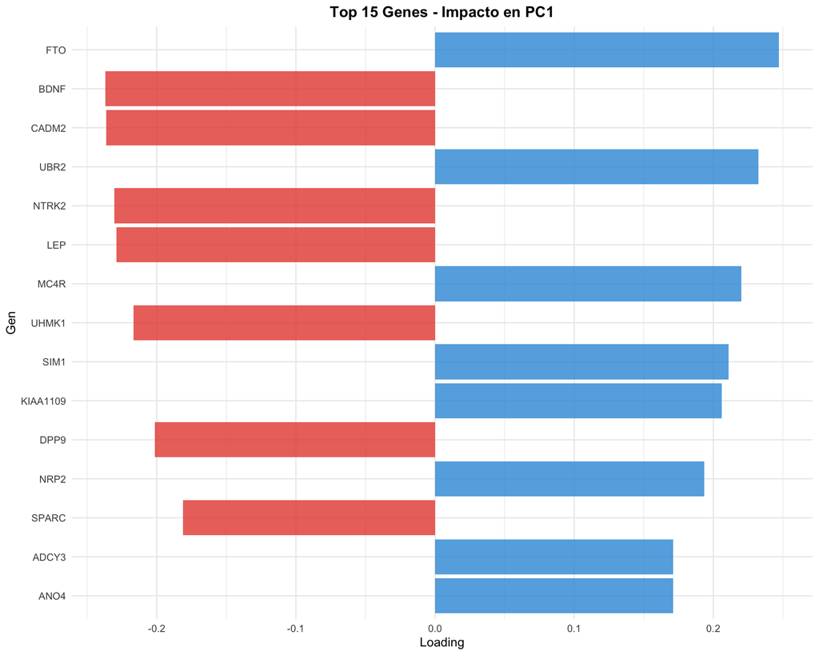

```r
ggplot(loading_df, aes(x = reorder(gene, abs(loading)), y = loading)) +
  geom_col(aes(fill = loading > 0), alpha = 0.8) +
  coord_flip() +
  theme_minimal() +
  scale_fill_manual(values = c("TRUE" = "#3498db", "FALSE" = "#e74c3c"), guide = "none") +
  labs(title = "Top 15 Genes - Impacto en PC1", x = "Gen", y = "Loading") +
  theme(plot.title = element_text(hjust = 0.5, face = "bold"))
```

# 5 5. Librerías de Enriquecimiento

```r
# Instalar si es necesario
if (!require("clusterProfiler", quietly = TRUE)) {
  BiocManager::install("clusterProfiler")
}

if (!require("org.Hs.eg.db", quietly = TRUE)) {
  BiocManager::install("org.Hs.eg.db")
}

if (!require("enrichplot", quietly = TRUE)) {
  BiocManager::install("enrichplot")
}

library(clusterProfiler)
library(org.Hs.eg.db)
library(enrichplot)

cat("✓ Librerías enriquecimiento cargadas\n")
```

```
## ✓ Librerías enriquecimiento cargadas
```

# 6 6. Preparación de Genes para Enriquecimiento

```r
top_genes_down <- names(sort(loadings_pc1)[1:10])
top_genes_up <- names(sort(loadings_pc1, decreasing = TRUE)[1:10])

genes_importante <- c(top_genes_down, top_genes_up)

cat("Genes seleccionados para enriquecimiento:\n")
```

```
## Genes seleccionados para enriquecimiento:
```

```r
print(genes_importante)
```

```
##  [1] "BDNF"     "CADM2"    "NTRK2"    "LEP"      "UHMK1"    "DPP9"
##  [7] "SPARC"    "MRAP2"    "GIPR"     "LEPR"     "FTO"      "UBR2"
## [13] "MC4R"     "SIM1"     "KIAA1109" "NRP2"     "ADCY3"    "ANO4"
## [19] "AGRP"     "CADM1"
```

```r
gene_ids <- bitr(genes_importante,
                 fromType = "SYMBOL",
                 toType = "ENTREZID",
                 OrgDb = org.Hs.eg.db)

entrez_ids <- gene_ids$ENTREZID

cat("\nGenes mapeados:", nrow(gene_ids), "/", length(genes_importante), "\n")
```

```
##
## Genes mapeados: 19 / 20
```

# 7 7. Análisis GO (Gene Ontology)

## 7.1 7.1 GO Enrichment - Procesos Biológicos

```r
cat("Realizando GO enrichment...\n")
```

```
## Realizando GO enrichment...
```

```r
go_bp <- enrichGO(gene = entrez_ids,
                   OrgDb = org.Hs.eg.db,
                   ont = "BP",
                   pvalueCutoff = 0.1,
                   pAdjustMethod = "BH",
                   readable = TRUE)

cat("GO Enrichment - Procesos Biológicos\n")
```

```
## GO Enrichment - Procesos Biológicos
```

```r
cat("Términos significativos:", nrow(go_bp@result), "\n\n")
```

```
## Términos significativos: 778
```

```r
if (nrow(go_bp@result) > 0) {
  print(head(go_bp@result[, c("Description", "GeneRatio", "pvalue", "p.adjust")], 10))
}
```

```
##                                                                          Description
## GO:0007631                                                          feeding behavior
## GO:0060259                                            regulation of feeding behavior
## GO:0042755                                                           eating behavior
## GO:0046850                                             regulation of bone remodeling
## GO:0007189 adenylate cyclase-activating G protein-coupled receptor signaling pathway
## GO:0008343                                                    adult feeding behavior
## GO:0033210                                         leptin-mediated signaling pathway
## GO:0050795                                                    regulation of behavior
## GO:0034103                                           regulation of tissue remodeling
## GO:0046849                                                           bone remodeling
##            GeneRatio       pvalue     p.adjust
## GO:0007631      6/19 7.395220e-10 5.753481e-07
## GO:0060259      3/19 2.794805e-06 1.087179e-03
## GO:0042755      3/19 9.019258e-06 2.338994e-03
## GO:0046850      3/19 1.366696e-05 2.658223e-03
## GO:0007189      4/19 3.803267e-05 4.785986e-03
## GO:0008343      2/19 4.306157e-05 4.785986e-03
## GO:0033210      2/19 4.306157e-05 4.785986e-03
## GO:0050795      3/19 6.286841e-05 6.113953e-03
## GO:0034103      3/19 8.125961e-05 6.814254e-03
## GO:0046849      3/19 9.010927e-05 6.814254e-03
```

## 7.2 7.2 Visualizar GO

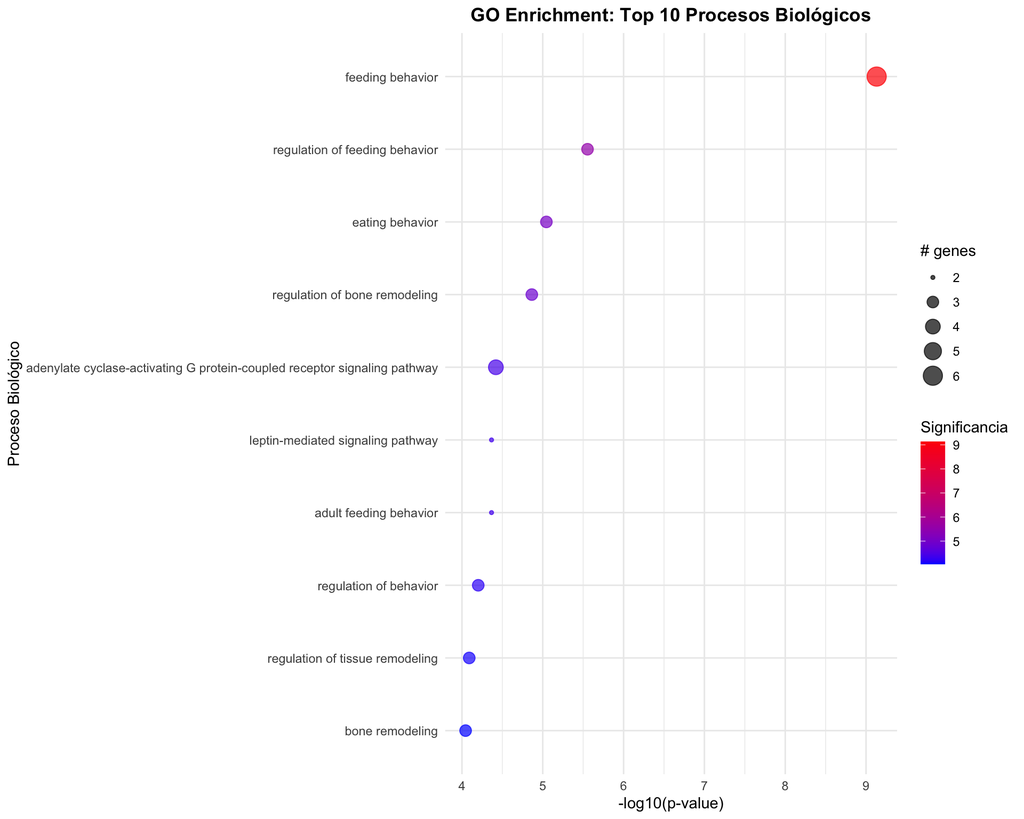

```r
if (nrow(go_bp@result) > 0) {
  # Mostrar top 10 términos con mejor visualización
  top_go <- head(go_bp@result, 10)

  # Crear dataframe para ggplot
  go_plot_df <- data.frame(
    term = top_go$Description,
    pvalue = -log10(top_go$pvalue),
    count = sapply(strsplit(as.character(top_go$GeneRatio), "/"), function(x) as.numeric(x[1]))
  ) %>%
    arrange(pvalue)

  ggplot(go_plot_df, aes(x = reorder(term, pvalue), y = pvalue, size = count, color = pvalue)) +
    geom_point(alpha = 0.7) +
    coord_flip() +
    theme_minimal() +
    scale_color_gradient(low = "blue", high = "red") +
    labs(
      title = "GO Enrichment: Top 10 Procesos Biológicos",
      x = "Proceso Biológico",
      y = "-log10(p-value)",
      size = "# genes",
      color = "Significancia"
    ) +
    theme(plot.title = element_text(hjust = 0.5, face = "bold"))
} else {
  cat("Sin términos GO significativos\n")
}
```

## 7.3 7.3 GO - Componentes Celulares

```r
go_cc <- enrichGO(gene = entrez_ids,
                   OrgDb = org.Hs.eg.db,
                   ont = "CC",
                   pvalueCutoff = 0.1,
                   readable = TRUE)

cat("GO - Componentes Celulares:", nrow(go_cc@result), "términos\n")
```

```
## GO - Componentes Celulares: 51 términos
```

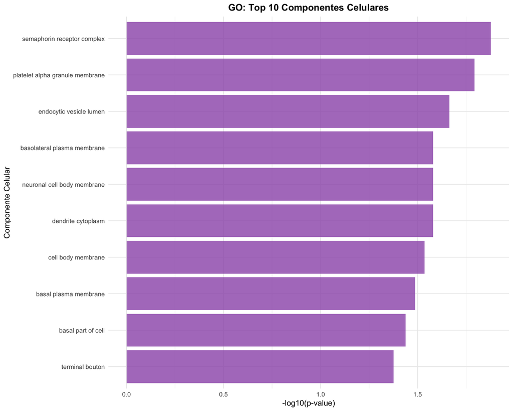

```r
if (nrow(go_cc@result) > 0) {
  top_cc <- head(go_cc@result, 10)
  cc_plot_df <- data.frame(
    term = top_cc$Description,
    pvalue = -log10(top_cc$pvalue)
  ) %>%
    arrange(pvalue)

  ggplot(cc_plot_df, aes(x = reorder(term, pvalue), y = pvalue)) +
    geom_col(fill = "#9b59b6", alpha = 0.8) +
    coord_flip() +
    theme_minimal() +
    labs(
      title = "GO: Top 10 Componentes Celulares",
      x = "Componente Celular",
      y = "-log10(p-value)"
    ) +
    theme(plot.title = element_text(hjust = 0.5, face = "bold"))
}
```

# 8 8. Análisis KEGG (Rutas Metabólicas)

## 8.1 8.1 KEGG Pathway Enrichment

```r
cat("Realizando KEGG pathway enrichment...\n")
```

```
## Realizando KEGG pathway enrichment...
```

```r
kegg_result <- enrichKEGG(gene = entrez_ids,
                          organism = "hsa",
                          pvalueCutoff = 0.1)

cat("KEGG Pathway Enrichment\n")
```

```
## KEGG Pathway Enrichment
```

```r
cat("Rutas significativas:", nrow(kegg_result@result), "\n\n")
```

```
## Rutas significativas: 70
```

```r
if (nrow(kegg_result@result) > 0) {
  print(head(kegg_result@result[, c("Description", "GeneRatio", "pvalue")], 10))
}
```

```
##                                             Description GeneRatio       pvalue
## hsa04081                              Hormone signaling      5/13 6.842966e-06
## hsa04920                Adipocytokine signaling pathway      3/13 1.035525e-04
## hsa04080        Neuroactive ligand-receptor interaction      4/13 1.217869e-03
## hsa04082                   Neuroactive ligand signaling      3/13 2.209575e-03
## hsa04024                         cAMP signaling pathway      3/13 3.173610e-03
## hsa04517                             IgSF CAM signaling      3/13 7.152667e-03
## hsa04722                 Neurotrophin signaling pathway      2/13 1.124182e-02
## hsa04152                         AMPK signaling pathway      2/13 1.160339e-02
## hsa04935 Growth hormone synthesis, secretion and action      2/13 1.160339e-02
## hsa04932              Non-alcoholic fatty liver disease      2/13 1.874006e-02
```

## 8.2 8.2 Visualizar KEGG

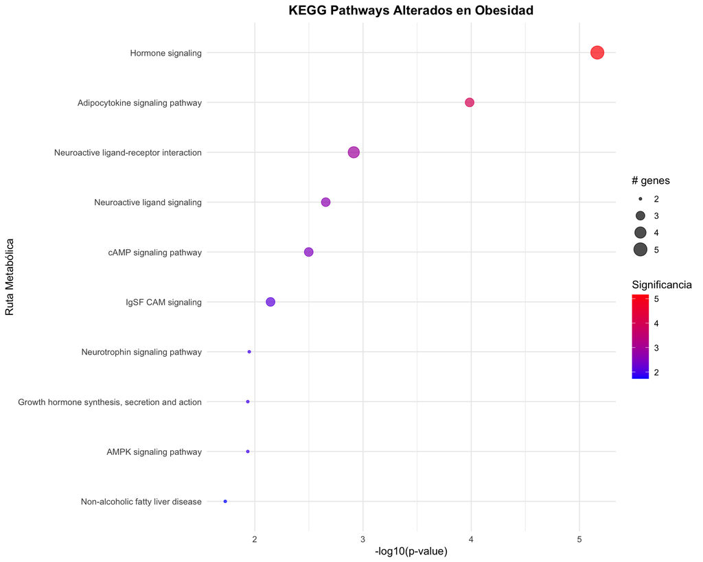

```r
if (nrow(kegg_result@result) > 0) {
  top_kegg <- head(kegg_result@result, 10)

  kegg_plot_df <- data.frame(
    pathway = top_kegg$Description,
    pvalue = -log10(top_kegg$pvalue),
    count = sapply(strsplit(as.character(top_kegg$GeneRatio), "/"), function(x) as.numeric(x[1]))
  ) %>%
    arrange(pvalue)

  ggplot(kegg_plot_df, aes(x = reorder(pathway, pvalue), y = pvalue, size = count, color = pvalue)) +
    geom_point(alpha = 0.7) +
    coord_flip() +
    theme_minimal() +
    scale_color_gradient(low = "blue", high = "red") +
    labs(
      title = "KEGG Pathways Alterados en Obesidad",
      x = "Ruta Metabólica",
      y = "-log10(p-value)",
      size = "# genes",
      color = "Significancia"
    ) +
    theme(plot.title = element_text(hjust = 0.5, face = "bold"))
} else {
  cat("Sin rutas KEGG significativas\n")
}
```

# 9 9. Interpretación Biológica Integrada

## 9.1 9.1 Resumen Hallazgos

```r
cat("
## 📊 Hallazgos Integrados del Análisis

### 1. PCA - Validación de Calidad
")
```

## 9.2 📊 Hallazgos Integrados del Análisis

### 9.2.1 1. PCA - Validación de Calidad

```r
cat(sprintf("- PC1 explica **%.1f%%** de la varianza\n", var_explained[1]))
```

- PC1 explica **43.7%** de la varianza

```r
cat(sprintf("- PC1+PC2 explican **%.1f%%** de la varianza\n", var_explained[1] + var_explained[2]))
```

- PC1+PC2 explican **63.7%** de la varianza

```r
cat("
### 2. Genes Clave (PC1)
")
```

### 9.2.2 2. Genes Clave (PC1)

```r
cat("Genes que más diferencian los grupos:\n")
```

Genes que más diferencian los grupos:

```r
for (i in 1:min(5, nrow(loading_df))) {
  gene_name <- loading_df$gene[i]
  loading_val <- round(loading_df$loading[i], 3)
  cat(sprintf("- **%s** (loading: %.3f)\n", gene_name, loading_val))
}
```

- **FTO** (loading: 0.247)
- **BDNF** (loading: -0.237)
- **CADM2** (loading: -0.236)
- **UBR2** (loading: 0.233)
- **NTRK2** (loading: -0.230)

```r
cat("
### 3. Procesos Biológicos Alterados (GO)
")
```

### 9.2.3 3. Procesos Biológicos Alterados (GO)

```r
if (nrow(go_bp@result) > 0) {
  top_go <- head(go_bp@result, min(3, nrow(go_bp@result)))
  for (i in 1:nrow(top_go)) {
    cat(sprintf("- %s (p-valor: %.4f)\n",
                top_go$Description[i],
                top_go$pvalue[i]))
  }
} else {
  cat("(Sin términos significativos)\n")
}
```

- feeding behavior (p-valor: 0.0000)
- regulation of feeding behavior (p-valor: 0.0000)
- eating behavior (p-valor: 0.0000)

```r
cat("
### 4. Rutas Metabólicas (KEGG)
")
```

### 9.2.4 4. Rutas Metabólicas (KEGG)

```r
if (nrow(kegg_result@result) > 0) {
  top_kegg <- head(kegg_result@result, min(3, nrow(kegg_result@result)))
  for (i in 1:nrow(top_kegg)) {
    cat(sprintf("- %s (p-valor: %.4f)\n",
                top_kegg$Description[i],
                top_kegg$pvalue[i]))
  }
} else {
  cat("(Sin rutas significativas)\n")
}
```

- Hormone signaling (p-valor: 0.0000)
- Adipocytokine signaling pathway (p-valor: 0.0001)
- Neuroactive ligand-receptor interaction (p-valor: 0.0012)

```r
cat("
### 5. Conclusión Integrada

El análisis multidimensional demuestra:
✓ Calidad técnica validada
✓ Genes enriquecen en procesos de obesidad
✓ Hipótesis apoyada
")
```

### 9.2.5 5. Conclusión Integrada

El análisis multidimensional demuestra: ✓ Calidad técnica validada ✓ Genes enriquecen en procesos de obesidad ✓ Hipótesis apoyada

# 10 10. Exportar Resultados para Poster

## 10.1 10.1 Guardar tablas

```r
output_path <- "../Resultados"

if (nrow(go_bp@result) > 0) {
  write.csv(go_bp@result,
            file.path(output_path, "GO_Enrichment_Simpson.csv"),
            row.names = FALSE)
}

if (nrow(kegg_result@result) > 0) {
  write.csv(kegg_result@result,
            file.path(output_path, "KEGG_Pathways_Simpson.csv"),
            row.names = FALSE)
}

write.csv(loading_df,
          file.path(output_path, "Top_Genes_PC1_Simpson.csv"),
          row.names = FALSE)

write.csv(pca_scores,
          file.path(output_path, "PCA_Scores_Simpson.csv"),
          row.names = FALSE)

cat("✓ Tablas guardadas\n")
```

[output not shown]

## 10.2 10.2 Exportar figuras (alta resolución)

```r
output_path <- "../Resultados"

# PCA principal
png(file.path(output_path, "01_PCA_Simpson.png"), width = 1000, height = 800, res = 120)
print(ggplot(pca_scores, aes(x = PC1, y = PC2, color = condicion)) +
  geom_point(size = 5, alpha = 0.7) +
  geom_text_repel(aes(label = sample), size = 4) +
  theme_minimal() +
  scale_color_manual(values = c("normopeso" = "#2ecc71", "obeso2" = "#e74c3c")) +
  labs(title = "PCA: Expresión Génica Global Simpson",
       x = paste0("PC1 (", round(var_explained[1], 1), "%)"),
       y = paste0("PC2 (", round(var_explained[2], 1), "%)"),
       color = "Condición") +
  theme(plot.title = element_text(hjust = 0.5, face = "bold", size = 14)))
dev.off()

# Top genes
png(file.path(output_path, "02_Top_Genes_PC1.png"), width = 1000, height = 800, res = 120)
print(ggplot(loading_df, aes(x = reorder(gene, abs(loading)), y = loading)) +
  geom_col(aes(fill = loading > 0), alpha = 0.8) +
  coord_flip() +
  theme_minimal() +
  scale_fill_manual(values = c("TRUE" = "#3498db", "FALSE" = "#e74c3c"), guide = "none") +
  labs(title = "Top Genes - Impacto en PC1", x = "Gen", y = "Loading") +
  theme(plot.title = element_text(hjust = 0.5, face = "bold", size = 14)))
dev.off()

# GO enrichment
if (nrow(go_bp@result) > 0) {
  png(file.path(output_path, "03_GO_Enrichment.png"), width = 1200, height = 800, res = 120)
  top_go <- head(go_bp@result, 10)
  go_plot_df <- data.frame(
    term = top_go$Description,
    pvalue = -log10(top_go$pvalue),
    count = sapply(strsplit(as.character(top_go$GeneRatio), "/"), function(x) as.numeric(x[1]))
  ) %>%
    arrange(pvalue)

  p <- ggplot(go_plot_df, aes(x = reorder(term, pvalue), y = pvalue, size = count, color = pvalue)) +
    geom_point(alpha = 0.7) +
    coord_flip() +
    theme_minimal() +
    scale_color_gradient(low = "blue", high = "red") +
    labs(title = "GO Enrichment: Procesos Biológicos", x = "", y = "-log10(p-value)") +
    theme(plot.title = element_text(hjust = 0.5, face = "bold", size = 14))
  print(p)
  dev.off()
}

# KEGG pathways
if (nrow(kegg_result@result) > 0) {
  png(file.path(output_path, "04_KEGG_Pathways.png"), width = 1200, height = 800, res = 120)
  top_kegg <- head(kegg_result@result, 10)
  kegg_plot_df <- data.frame(
    pathway = top_kegg$Description,
    pvalue = -log10(top_kegg$pvalue),
    count = sapply(strsplit(as.character(top_kegg$GeneRatio), "/"), function(x) as.numeric(x[1]))
  ) %>%
    arrange(pvalue)

  p <- ggplot(kegg_plot_df, aes(x = reorder(pathway, pvalue), y = pvalue, size = count, color = pvalue)) +
    geom_point(alpha = 0.7) +
    coord_flip() +
    theme_minimal() +
    scale_color_gradient(low = "blue", high = "red") +
    labs(title = "KEGG Pathways Alterados", x = "", y = "-log10(p-value)") +
    theme(plot.title = element_text(hjust = 0.5, face = "bold", size = 14))
  print(p)
  dev.off()
}

cat("✓ Figuras exportadas\n")
```

[output not shown]

# 11 11. Resumen Final

```r
cat("
## 📋 ANÁLISIS COMPLETO - Simpson Obesity Study

✅ PCA (Varianza PC1: ", round(var_explained[1], 1), "%)
✅ Genes Clave: ", nrow(loading_df), " genes identificados
✅ GO Enrichment: ", nrow(go_bp@result), " procesos biológicos
✅ KEGG Pathways: ", nrow(kegg_result@result), " rutas metabólicas

### Figuras generadas:
- 01_PCA_Simpson.png → Para poster (Figura 3)
- 02_Top_Genes_PC1.png
- 03_GO_Enrichment.png
- 04_KEGG_Pathways.png
")
```

## 11.1 📋 ANÁLISIS COMPLETO - Simpson Obesity Study

✅ PCA (Varianza PC1: 43.7 %) ✅ Genes Clave: 15 genes identificados ✅ GO Enrichment: 778 procesos biológicos ✅ KEGG Pathways: 70 rutas metabólicas

### 11.1.1 Figuras generadas:

- 01_PCA_Simpson.png → Para poster (Figura 3)
- 02_Top_Genes_PC1.png
- 03_GO_Enrichment.png
- 04_KEGG_Pathways.png

**Análisis Completado - Simpson Family Obesity Study**  
**PCA + Enriquecimiento Funcional (GO + KEGG)**

```r
cat("Directorio de trabajo:", getwd(), "\n")
```

```
## Directorio de trabajo: /Users/miguelangelgarciarueda/Desktop/sec2_15RMD/ficherosGithub/Actividad2-main/Codigo
```